# Data Summary Final

Kim Pham

5/18/2019

## Data Summary

#### Instructions

- brief report that summarizes the core features of the data and calls out interesting trends, etc.
- form of a notebook-like document
- audience is other data scientists who need to understand dataset

### Data Summary Outline

- In this RMD we will look at the data structure of the cleaned and processed data.
- Remember our project is interested in looking at predicted tip values, so let’s pay close attention to that as we look at the dataset.

### Load libraries

```r
library(dplyr)
library(ggplot2)
```

### Load cleaned data set

The cleaned datset is saved as an RData file in the data folder (i.e. df.rds) and contains a cleaned dataset of NYC yellow cab data from the months of March, June, and November in 2017.

The dataExploration.rmd file details the cleaning and processing steps, which includes: * combining the datafiles from each month, * checking for missing values, * reconfirming the observed values make sense, and * removing variables and observations not relevant to our analysis.

The data is downloaded and accessed here: [NYC Taxi & Limousine Commission - Trip Record Data](https://www1.nyc.gov/site/tlc/about/tlc-trip-record-data.page) The [Data Dictionary](https://www1.nyc.gov/assets/tlc/downloads/pdf/data_dictionary_trip_records_yellow.pdf) details the variables and its values.

```r
my_data <- readRDS("data/df.rds")
```

### Data Structure

```r
paste0("The data set has ", nrow(my_data), " NYC taxi trip observations.")
```

```
## [1] "The data set has 29120154 NYC taxi trip observations."
```

```r
paste0("There are ", ncol(my_data), " variables describing those trips.")
```

```
## [1] "There are 15 variables describing those trips."
```

```r
paste("The variables are below:")
```

```
## [1] "The variables are below:"
```

```r
paste(colnames(my_data))
```

```
##  [1] "VendorID"              "tpep_pickup_datetime"
##  [3] "tpep_dropoff_datetime" "passenger_count"
##  [5] "trip_distance"         "RatecodeID"
##  [7] "store_and_fwd_flag"    "payment_type"
##  [9] "fare_amount"           "extra"
## [11] "mta_tax"               "tip_amount"
## [13] "tolls_amount"          "improvement_surcharge"
## [15] "total_amount"
```

```r
str(my_data)
```

```
## Classes 'tbl_df', 'tbl' and 'data.frame':    29120154 obs. of  15 variables:
##  $ VendorID             : num  2 2 2 2 2 2 2 2 2 1 ...
##  $ tpep_pickup_datetime : POSIXct, format: "2017-03-09 21:30:11" "2017-03-09 21:47:00" ...
##  $ tpep_dropoff_datetime: POSIXct, format: "2017-03-09 21:44:20" "2017-03-09 21:58:01" ...
##  $ passenger_count      : num  1 1 1 1 1 1 1 1 5 1 ...
##  $ trip_distance        : num  4.06 2.73 2.27 3.86 3.45 4.21 2.84 0.58 0.4 0.9 ...
##  $ RatecodeID           : num  1 1 1 1 1 1 1 1 1 1 ...
##  $ store_and_fwd_flag   : chr  "N" "N" "N" "N" ...
##  $ payment_type         : num  1 2 1 1 2 1 2 1 1 1 ...
##  $ fare_amount          : num  14 11.5 10 12 12 20.5 12 4.5 4 7 ...
##  $ extra                : num  0.5 0.5 0.5 0.5 0.5 0 0 0 0 0 ...
##  $ mta_tax              : num  0.5 0.5 0.5 0.5 0.5 0.5 0.5 0.5 0.5 0.5 ...
##  $ tip_amount           : num  3.06 0 2.82 3.99 0 4.26 0 1.59 1.2 1.55 ...
##  $ tolls_amount         : num  0 0 0 0 0 0 0 0 0 0 ...
##  $ improvement_surcharge: num  0.3 0.3 0.3 0.3 0.3 0.3 0.3 0.3 0.3 0.3 ...
##  $ total_amount         : num  18.4 12.8 14.1 17.3 13.3 ...
```

```r
head(my_data,10) # top 10 rows preview
```

```
## # A tibble: 10 x 15
##    VendorID tpep_pickup_dateti… tpep_dropoff_datet… passenger_count
##       <dbl> <dttm>              <dttm>                        <dbl>
##  1        2 2017-03-09 21:30:11 2017-03-09 21:44:20               1
##  2        2 2017-03-09 21:47:00 2017-03-09 21:58:01               1
##  3        2 2017-03-09 22:01:08 2017-03-09 22:11:16               1
##  4        2 2017-03-09 22:16:05 2017-03-10 06:26:11               1
##  5        2 2017-03-31 06:31:53 2017-03-31 06:41:48               1
##  6        2 2017-03-15 00:07:59 2017-03-15 00:38:08               1
##  7        2 2017-03-10 14:09:10 2017-03-10 14:24:38               1
##  8        2 2017-03-10 14:09:10 2017-03-10 14:13:37               1
##  9        2 2017-03-10 14:09:10 2017-03-10 14:12:11               5
## 10        1 2017-03-10 14:09:11 2017-03-10 14:17:07               1
## # ... with 11 more variables: trip_distance <dbl>, RatecodeID <dbl>,
## #   store_and_fwd_flag <chr>, payment_type <dbl>, fare_amount <dbl>,
## #   extra <dbl>, mta_tax <dbl>, tip_amount <dbl>, tolls_amount <dbl>,
## #   improvement_surcharge <dbl>, total_amount <dbl>
```

```r
tail(my_data,10) # bottom 10 rows preview
```

```
## # A tibble: 10 x 15
##    VendorID tpep_pickup_dateti… tpep_dropoff_datet… passenger_count
##       <dbl> <dttm>              <dttm>                        <dbl>
##  1        2 2017-11-30 23:19:49 2017-11-30 23:24:42               1
##  2        2 2017-11-30 23:39:02 2017-11-30 23:43:19               1
##  3        2 2017-11-30 23:26:16 2017-11-30 23:40:26               1
##  4        2 2017-11-30 23:08:42 2017-11-30 23:13:43               1
##  5        2 2017-11-30 23:14:49 2017-11-30 23:26:08               1
##  6        2 2017-11-30 23:27:24 2017-11-30 23:48:15               1
##  7        1 2017-11-30 23:59:05 2017-11-30 23:59:14               1
##  8        2 2017-11-30 23:17:20 2017-11-30 23:39:33               1
##  9        2 2017-11-30 22:52:40 2017-11-30 23:27:26               1
## 10        2 2017-11-30 23:33:39 2017-11-30 23:42:54               1
## # ... with 11 more variables: trip_distance <dbl>, RatecodeID <dbl>,
## #   store_and_fwd_flag <chr>, payment_type <dbl>, fare_amount <dbl>,
## #   extra <dbl>, mta_tax <dbl>, tip_amount <dbl>, tolls_amount <dbl>,
## #   improvement_surcharge <dbl>, total_amount <dbl>
```

### Quick Visualizations and Summaries of Variables

#### Overall Average Tips Received

```r
avg_tip <- my_data %>% summarise(average_tip=mean(tip_amount))
avg_tip
```

```
## # A tibble: 1 x 1
##   average_tip
##         <dbl>
## 1        1.87
```

#### Average Tips Received by Vendor Taxi Reports

```r
vcount <- my_data %>% group_by(VendorID) %>% count() %>% as.data.frame()
vtip <- my_data %>% group_by(VendorID) %>% summarise(average_tip=mean(tip_amount)) %>% as.data.frame()
vendor <- left_join(vcount,vtip,by="VendorID")
vendor
```

```
##   VendorID        n average_tip
## 1        1 13195819    1.831776
## 2        2 15924335    1.909746
```

There are more taxi reports from vendor 2=VeriFone Inc. The average tip amounts are higher in the reports by vendor 2=VeriFone Inc.

#### Average Tips Received by Payment Type

[output not shown]

```r
paycount <- my_data %>% group_by(payment_type) %>% count() %>% as.data.frame()
paytip <- my_data %>% group_by(payment_type) %>% summarise(average_tip=mean(tip_amount)) %>% as.data.frame()
paytype <- left_join(paycount,paytip,by="payment_type")
paytype
```

```
##   payment_type        n   average_tip
## 1            1 19768477  2.761139e+00
## 2            2  9155558  7.536406e-07
## 3            3   152817 -2.037404e-03
## 4            4    43301  1.288654e-04
## 5            5        1  0.000000e+00
```

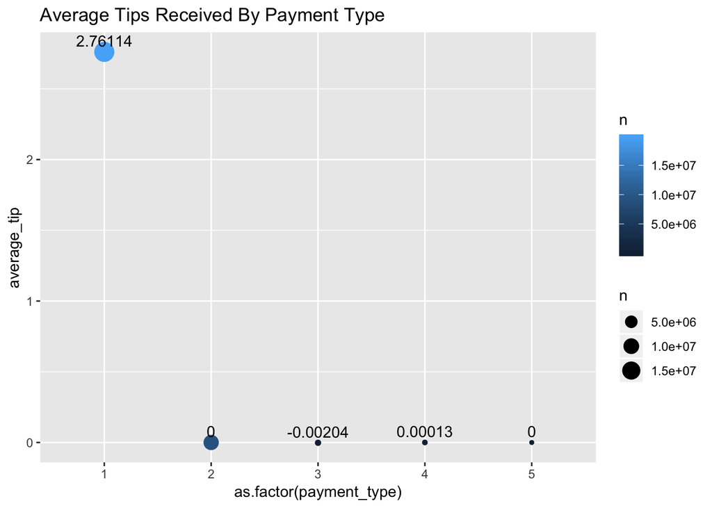

```r
ggplot(data=paytype)+geom_point(aes(x=as.factor(payment_type),y=average_tip,size=n,color=n))+ggtitle("Average Tips Received By Payment Type")+geom_text(aes(x=as.factor(payment_type),y=average_tip,label = round(average_tip,5)), vjust = -.5)
```

It’s a bit unclear where the negative average tip comes from, which only relates to “no charge” payment types. Let’s visually look at the distribution of payment types.

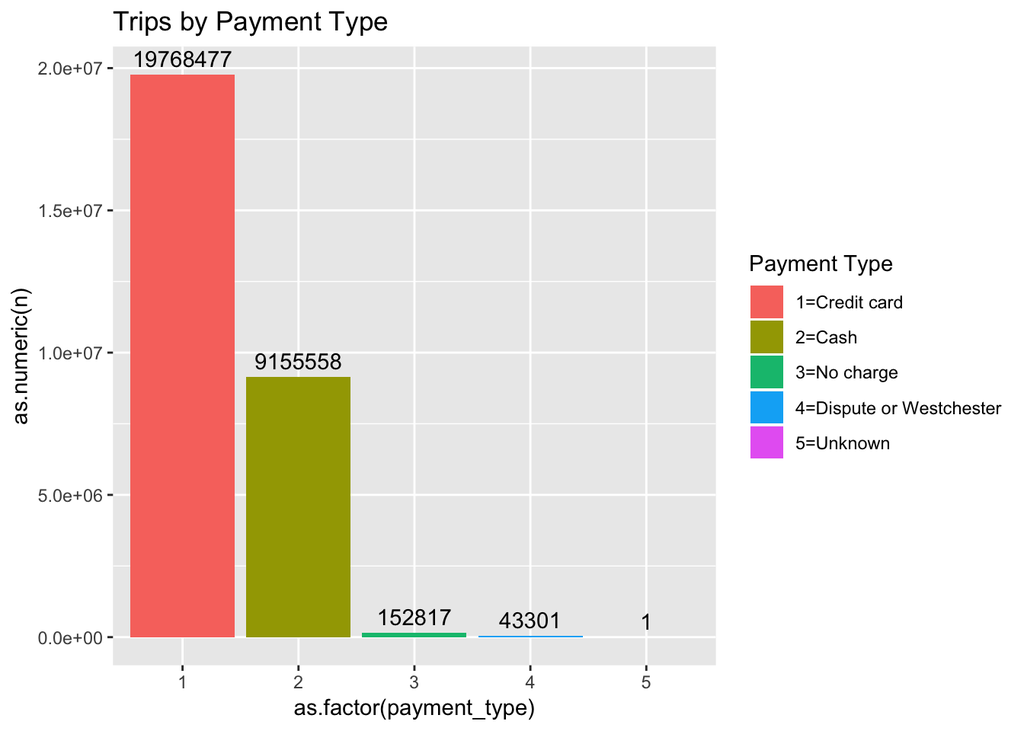

```r
ggplot(data=paytype, aes(x=as.factor(payment_type), y=as.numeric(n),fill=as.factor(payment_type)))+geom_bar(stat="identity")+ggtitle("Trips by Payment Type")+geom_text(aes(label = n), vjust = -.5)+scale_fill_discrete(
    name="Payment Type",
    breaks=c("1", "2", "3", "4", "5"),
    labels=c("1=Credit card","2=Cash","3=No charge","4=Dispute or Westchester","5=Unknown"))
```

Most payments are made by credit card and then cash. However, it looks like credit cards have the highest average tips (i.e. 2.76) while all other payment types are close to 0 average tips.

#### Taxi Trips by Count of Passengers

```r
pcount <- my_data %>% group_by(passenger_count) %>% count() %>% as.data.frame()
ptip <- my_data %>% group_by(passenger_count) %>% summarise(average_tip=mean(tip_amount)) %>% as.data.frame()
pass <- left_join(pcount,ptip,by="passenger_count")
pass
```

```
##   passenger_count        n average_tip
## 1               1 20915936    1.879624
## 2               2  4210325    1.885726
## 3               3  1202357    1.794119
## 4               4   557433    1.692082
## 5               5  1384630    1.899166
## 6               6   849232    1.881699
## 7               7       88    4.690227
## 8               8       87    7.823333
## 9               9       66    7.267273
```

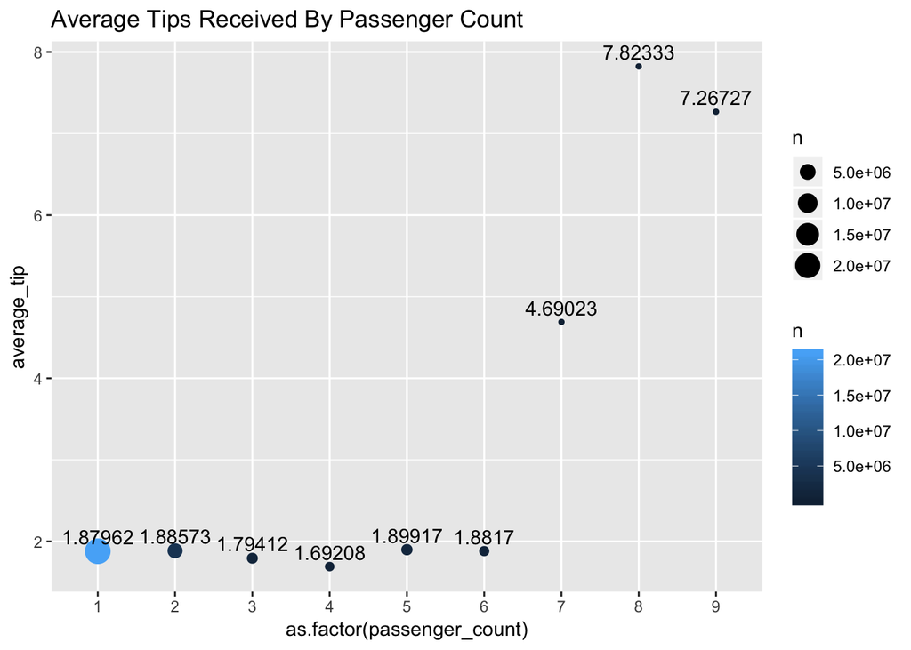

```r
ggplot(data=pass)+geom_point(aes(x=as.factor(passenger_count),y=average_tip,size=n,color=n))+ggtitle("Average Tips Received By Passenger Count")+geom_text(aes(x=as.factor(passenger_count),y=average_tip,label = round(average_tip,5)), vjust = -.5)
```

N describes the n size of the passenger_counts. The graph uses a scaled color and point size to compare the n sizes between the different passenger_counts. Most often taxi trips have one passenger and least often taxi trips have more than 6 passengers. However, the average tips received are greater when trips have more than 6 passengers.

#### Taxi Trip Records by Stored and Forwarded Data

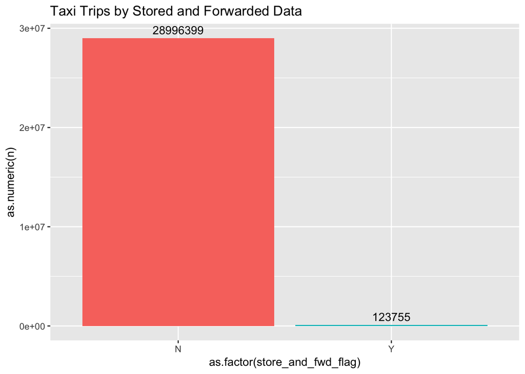

```r
stofor <- my_data %>% group_by(store_and_fwd_flag) %>% count() %>% as.data.frame()
ggplot(data=stofor, aes(x=as.factor(store_and_fwd_flag), y=as.numeric(n),fill=as.factor(store_and_fwd_flag)))+geom_bar(stat="identity")+ggtitle("Taxi Trips by Stored and Forwarded Data")+geom_text(aes(label = n), vjust = -.5)+guides(fill=FALSE)
```

The majority of taxi trip records are forwarded, and not stored in vehicle memory prior to being forwarded. Most taxi trips have connection to the server to forward and send data.

#### Taxi Trips by RateCodeID

| Payment Id | Payment Type |
| --- | --- |
| 1 | Standard rate |
| 2 | JFK |
| 3 | Newark |
| 4 | Nassau or Westchester |
| 5 | Negotiated fare |
| 6 | Group ride |

```r
codeid <- my_data %>% group_by(RatecodeID) %>% count() %>% as.data.frame()
codetip <- my_data %>% group_by(RatecodeID) %>% summarise(average_tip=mean(tip_amount)) %>% as.data.frame()
code <- left_join(codeid,codetip,by="RatecodeID")
code
```

```
##   RatecodeID        n average_tip
## 1          1 28295446    1.705251
## 2          2   650880    7.478971
## 3          3    61738   10.698136
## 4          4    15441    8.170572
## 5          5    96409    7.026147
## 6          6      240    1.823542
```

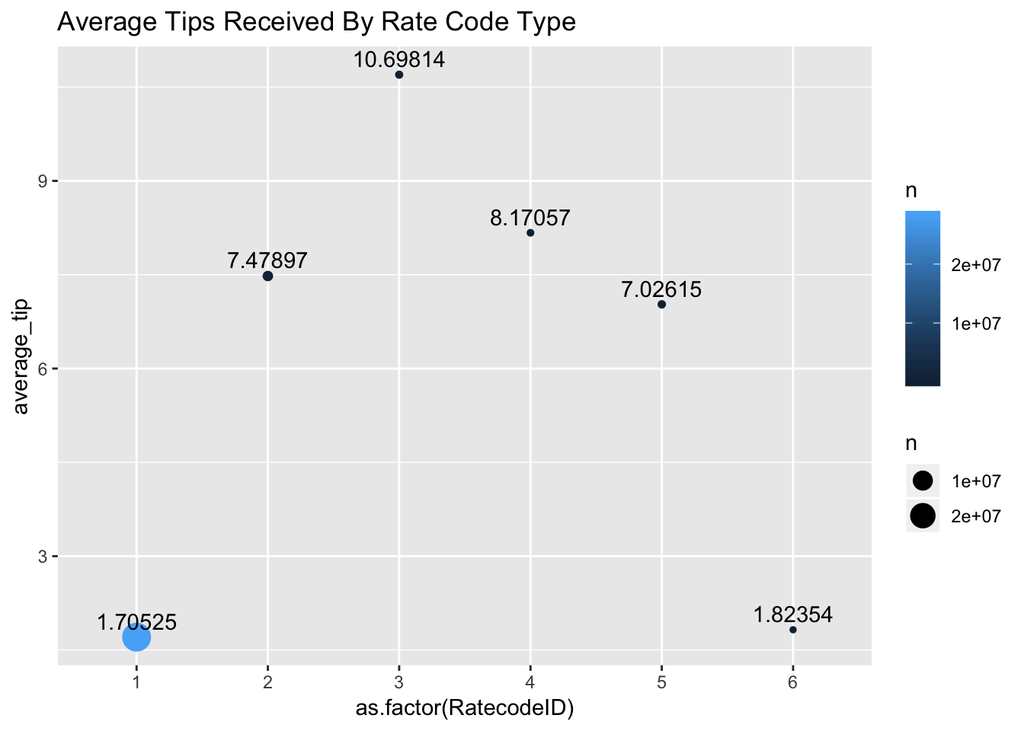

```r
ggplot(data=code)+geom_point(aes(x=as.factor(RatecodeID),y=average_tip,size=n,color=n))+ggtitle("Average Tips Received By Rate Code Type")+geom_text(aes(x=as.factor(RatecodeID),y=average_tip,label = round(average_tip,5)), vjust = -.5)
```

Trips with rate codes of Newark, Nassau or Westchester, JFK, and Negotiated Fare receive the highest tips on average (in that order).

#### Trip Distances

```r
average_distance <- my_data%>%group_by(RatecodeID)%>%summarise(average_distance=mean(trip_distance))
code <- left_join(code,average_distance,by="RatecodeID")
code
```

```
##   RatecodeID        n average_tip average_distance
## 1          1 28295446    1.705251         2.540402
## 2          2   650880    7.478971        17.211860
## 3          3    61738   10.698136        16.375521
## 4          4    15441    8.170572        18.036348
## 5          5    96409    7.026147         6.321651
## 6          6      240    1.823542         1.237000
```

The type of rate codes that receive the highest tips on average (i.e. Newark, Nassau or Westchester, JFK, and Negotiated Fare) are the trips with the greatest average_distances.